# Student 3000 Criminal Data

coop711

2015년 10월 7일

## Structure of Data

### Data Manipulation

- W. S. Gosset 이 t-분포를 유도하느라고 모의실험에 활용한 자료는 다음과 같음.
  - `table`은 본질적으로 `matrix`임. 행과 열의 이름에 측정값을 글자로 새겨 넣었기 때문에 long format으로 변환할 때 많은 주의가 필요함.

```r
# options(width=132)
crimtab
```

```
##      142.24 144.78 147.32 149.86 152.4 154.94 157.48 160.02 162.56 165.1
## 9.4       0      0      0      0     0      0      0      0      0     0
## 9.5       0      0      0      0     0      1      0      0      0     0
## 9.6       0      0      0      0     0      0      0      0      0     0
## 9.7       0      0      0      0     0      0      0      0      0     0
## 9.8       0      0      0      0     0      0      1      0      0     0
## 9.9       0      0      1      0     1      0      1      0      0     0
## 10        1      0      0      1     2      0      2      0      0     1
## 10.1      0      0      0      1     3      1      0      1      1     0
## 10.2      0      0      2      2     2      1      0      2      0     1
## 10.3      0      1      1      3     2      2      3      5      0     0
## 10.4      0      0      1      1     2      3      3      4      3     3
## 10.5      0      0      0      1     3      7      6      4      3     1
## 10.6      0      0      0      1     4      5      9     14      6     3
## 10.7      0      0      1      2     4      9     14     16     15     7
## 10.8      0      0      0      2     5      6     14     27     10     7
## 10.9      0      0      0      0     2      6     14     24     27    14
## 11        0      0      0      2     6     12     15     31     37    27
## 11.1      0      0      0      3     3     12     22     26     24    26
## 11.2      0      0      0      3     2      7     21     30     38    29
## 11.3      0      0      0      1     0      5     10     24     26    39
## 11.4      0      0      0      0     3      4      9     29     56    58
## 11.5      0      0      0      0     0      5     11     17     33    57
## 11.6      0      0      0      0     2      1      4     13     37    39
## 11.7      0      0      0      0     0      2      9     17     30    37
## 11.8      0      0      0      0     1      0      2     11     15    35
## 11.9      0      0      0      0     1      1      2     12     10    27
## 12        0      0      0      0     0      0      1      4      8    19
## 12.1      0      0      0      0     0      0      0      2      4    13
## 12.2      0      0      0      0     0      0      1      2      5     6
## 12.3      0      0      0      0     0      0      0      0      4     8
## 12.4      0      0      0      0     0      0      1      1      1     2
## 12.5      0      0      0      0     0      0      0      1      0     1
## 12.6      0      0      0      0     0      0      0      0      0     1
## 12.7      0      0      0      0     0      0      0      0      0     1
## 12.8      0      0      0      0     0      0      0      0      0     0
## 12.9      0      0      0      0     0      0      0      0      0     0
## 13        0      0      0      0     0      0      0      0      0     0
## 13.1      0      0      0      0     0      0      0      0      0     0
## 13.2      0      0      0      0     0      0      0      0      0     0
```

[output cut: 74 more lines]

```
## 12.1      0      0
## 12.2      0      0
## 12.3      0      0
## 12.4      0      0
## 12.5      0      0
## 12.6      0      0
## 12.7      0      0
## 12.8      0      0
## 12.9      0      0
## 13        0      0
## 13.1      0      0
## 13.2      0      0
## 13.3      0      0
## 13.4      0      0
## 13.5      0      0
```

```r
str(crimtab)
```

```
##  'table' int [1:42, 1:22] 0 0 0 0 0 0 1 0 0 0 ...
##  - attr(*, "dimnames")=List of 2
##   ..$ : chr [1:42] "9.4" "9.5" "9.6" "9.7" ...
##   ..$ : chr [1:22] "142.24" "144.78" "147.32" "149.86" ...
```

- 이러한 table 구조의 행과 열에 이름을 붙이려면, `list`로 부여
  - cm 단위로 되어 있는 키의 계급을 인치 단위로 변환하면 숨어있던 자료구조다 드러남.

```r
dimnames(crimtab)
```

```
## [[1]]
##  [1] "9.4"  "9.5"  "9.6"  "9.7"  "9.8"  "9.9"  "10"   "10.1" "10.2" "10.3"
## [11] "10.4" "10.5" "10.6" "10.7" "10.8" "10.9" "11"   "11.1" "11.2" "11.3"
## [21] "11.4" "11.5" "11.6" "11.7" "11.8" "11.9" "12"   "12.1" "12.2" "12.3"
## [31] "12.4" "12.5" "12.6" "12.7" "12.8" "12.9" "13"   "13.1" "13.2" "13.3"
## [41] "13.4" "13.5"
##
## [[2]]
##  [1] "142.24" "144.78" "147.32" "149.86" "152.4"  "154.94" "157.48"
##  [8] "160.02" "162.56" "165.1"  "167.64" "170.18" "172.72" "175.26"
## [15] "177.8"  "180.34" "182.88" "185.42" "187.96" "190.5"  "193.04"
## [22] "195.58"
```

```r
crimtab.2 <- crimtab
colnames(crimtab.2) <- as.numeric(colnames(crimtab.2))/2.54
(dimnames(crimtab.2) <- list(finger = rownames(crimtab.2), height = colnames(crimtab.2)))
```

```
## $finger
##  [1] "9.4"  "9.5"  "9.6"  "9.7"  "9.8"  "9.9"  "10"   "10.1" "10.2" "10.3"
## [11] "10.4" "10.5" "10.6" "10.7" "10.8" "10.9" "11"   "11.1" "11.2" "11.3"
## [21] "11.4" "11.5" "11.6" "11.7" "11.8" "11.9" "12"   "12.1" "12.2" "12.3"
## [31] "12.4" "12.5" "12.6" "12.7" "12.8" "12.9" "13"   "13.1" "13.2" "13.3"
## [41] "13.4" "13.5"
##
## $height
##  [1] "56" "57" "58" "59" "60" "61" "62" "63" "64" "65" "66" "67" "68" "69"
## [15] "70" "71" "72" "73" "74" "75" "76" "77"
```

```r
crimtab.2
```

```
##       height
## finger 56 57 58 59 60 61 62 63 64 65 66 67 68 69 70 71 72 73 74 75 76 77
##   9.4   0  0  0  0  0  0  0  0  0  0  0  0  0  0  0  0  0  0  0  0  0  0
##   9.5   0  0  0  0  0  1  0  0  0  0  0  0  0  0  0  0  0  0  0  0  0  0
##   9.6   0  0  0  0  0  0  0  0  0  0  0  0  0  0  0  0  0  0  0  0  0  0
##   9.7   0  0  0  0  0  0  0  0  0  0  0  0  0  0  0  0  0  0  0  0  0  0
##   9.8   0  0  0  0  0  0  1  0  0  0  0  0  0  0  0  0  0  0  0  0  0  0
##   9.9   0  0  1  0  1  0  1  0  0  0  0  0  0  0  0  0  0  0  0  0  0  0
##   10    1  0  0  1  2  0  2  0  0  1  0  0  0  0  0  0  0  0  0  0  0  0
##   10.1  0  0  0  1  3  1  0  1  1  0  0  0  0  0  0  0  0  0  0  0  0  0
##   10.2  0  0  2  2  2  1  0  2  0  1  0  0  0  0  0  0  0  0  0  0  0  0
##   10.3  0  1  1  3  2  2  3  5  0  0  0  0  0  0  0  0  0  0  0  0  0  0
##   10.4  0  0  1  1  2  3  3  4  3  3  0  0  0  0  0  0  0  0  0  0  0  0
##   10.5  0  0  0  1  3  7  6  4  3  1  3  1  0  1  0  0  0  0  0  0  0  0
##   10.6  0  0  0  1  4  5  9 14  6  3  1  0  0  1  0  0  0  0  0  0  0  0
##   10.7  0  0  1  2  4  9 14 16 15  7  3  1  2  0  0  0  0  0  0  0  0  0
##   10.8  0  0  0  2  5  6 14 27 10  7  1  2  1  0  0  0  0  0  0  0  0  0
##   10.9  0  0  0  0  2  6 14 24 27 14 10  4  1  0  0  0  0  0  0  0  0  0
##   11    0  0  0  2  6 12 15 31 37 27 17 10  6  0  0  0  0  0  0  0  0  0
##   11.1  0  0  0  3  3 12 22 26 24 26 24  7  4  1  0  0  0  0  0  0  0  0
##   11.2  0  0  0  3  2  7 21 30 38 29 27 20  4  1  0  0  0  0  0  0  0  1
##   11.3  0  0  0  1  0  5 10 24 26 39 26 24  7  2  0  0  0  0  0  0  0  0
##   11.4  0  0  0  0  3  4  9 29 56 58 26 22 10 11  0  0  0  0  0  0  0  0
##   11.5  0  0  0  0  0  5 11 17 33 57 38 34 25 11  2  0  0  0  0  0  0  0
##   11.6  0  0  0  0  2  1  4 13 37 39 48 38 27 12  2  2  0  1  0  0  0  0
##   11.7  0  0  0  0  0  2  9 17 30 37 48 45 24  9  9  2  0  0  0  0  0  0
##   11.8  0  0  0  0  1  0  2 11 15 35 41 34 29 10  5  1  0  0  0  0  0  0
##   11.9  0  0  0  0  1  1  2 12 10 27 32 35 19 10  9  3  1  0  0  0  0  0
##   12    0  0  0  0  0  0  1  4  8 19 42 39 22 16  8  2  2  0  0  0  0  0
##   12.1  0  0  0  0  0  0  0  2  4 13 22 28 15 27 10  4  1  0  0  0  0  0
##   12.2  0  0  0  0  0  0  1  2  5  6 23 17 16 11  8  1  1  0  0  0  0  0
##   12.3  0  0  0  0  0  0  0  0  4  8 10 13 20 23  6  5  0  0  0  0  0  0
##   12.4  0  0  0  0  0  0  1  1  1  2  7 12  4  7  7  1  0  0  1  0  0  0
##   12.5  0  0  0  0  0  0  0  1  0  1  3 12 11  8  6  8  0  2  0  0  0  0
##   12.6  0  0  0  0  0  0  0  0  0  1  0  3  5  7  8  6  3  1  1  0  0  0
##   12.7  0  0  0  0  0  0  0  0  0  1  1  7  5  5  8  2  2  0  0  0  0  0
##   12.8  0  0  0  0  0  0  0  0  0  0  1  2  3  1  8  5  3  1  1  0  0  0
##   12.9  0  0  0  0  0  0  0  0  0  0  0  1  2  2  0  1  1  0  0  0  0  0
##   13    0  0  0  0  0  0  0  0  0  0  3  0  1  0  1  0  2  1  0  0  0  0
##   13.1  0  0  0  0  0  0  0  0  0  0  0  1  1  0  0  0  0  0  0  0  0  0
##   13.2  0  0  0  0  0  0  0  0  0  0  1  1  0  1  0  3  0  0  0  0  0  0
##   13.3  0  0  0  0  0  0  0  0  0  0  0  0  0  0  0  0  1  0  1  0  0  0
##   13.4  0  0  0  0  0  0  0  0  0  0  0  0  0  0  0  0  0  0  0  0  0  0
##   13.5  0  0  0  0  0  0  0  0  0  0  0  0  0  0  0  0  0  1  0  0  0  0
```

```r
str(crimtab.2)
```

```
##  'table' int [1:42, 1:22] 0 0 0 0 0 0 1 0 0 0 ...
##  - attr(*, "dimnames")=List of 2
##   ..$ finger: chr [1:42] "9.4" "9.5" "9.6" "9.7" ...
##   ..$ height: chr [1:22] "56" "57" "58" "59" ...
```

- long format 으로 변환
  - 1차적으로 각 손가락 길이와 키의 조합을 갖는 인원수로 구성된 data frame으로 변환하고, case 단위의 long format data frame으로 2단계 변환
  - `as.data.frame()` 에서 `stringsAsFactors = FALSE`가 매우 중요한 역할을 하는 것임. 이 옵션을 설정하지 않을 경우 `Factor`로 잡히면 `numeric`으로 전환할 수 없게 됨. `Factor`는 본질적으로 음이 아닌 정수로 취급됨.
  - 보통 이 설정은 `stringsAsFactors = default.stringsAsFactors()`가 default 설정으로 되어 있고, 따라서 `default.stringsAsFactors() =` FALSE 에 따라 설정을 바꿔주면 되어야 하나 써 있는 대로 되지 않는 경우가 있어서 가능한 설정해주는 것이 안전함.
  - 단순히 `data.frame()`으로 변환할 경우 `Factor`로 설정되어`numeric`으로 변환하더라도 의미없는 숫자를 얻게 됨.
  - `as.data.frame()`의 결과물로 두 개의 character vector 와 counts를 나타내는 새로운 변수 `Freq`가 나오게 됨. 손가락 길이와 키를 나타내는 character를 numeric으로 전환하고 다음 작업 진행.

```r
crimtab.2.df <- as.data.frame(crimtab.2, stringsAsFactors = FALSE)
str(crimtab.2.df)
```

```
## 'data.frame':    924 obs. of  3 variables:
##  $ finger: chr  "9.4" "9.5" "9.6" "9.7" ...
##  $ height: chr  "56" "56" "56" "56" ...
##  $ Freq  : int  0 0 0 0 0 0 1 0 0 0 ...
```

```r
crimtab.2.df[1:2] <- sapply(crimtab.2.df[1:2], as.numeric)
str(crimtab.2.df)
```

```
## 'data.frame':    924 obs. of  3 variables:
##  $ finger: num  9.4 9.5 9.6 9.7 9.8 9.9 10 10.1 10.2 10.3 ...
##  $ height: num  56 56 56 56 56 56 56 56 56 56 ...
##  $ Freq  : int  0 0 0 0 0 0 1 0 0 0 ...
```

```r
crimtab.2.long <- mapply(function(x) rep(x, crimtab.2.df$Freq), crimtab.2.df[c("finger", "height")])
# crimtab.2.long <- mapply(function(x, y) rep(x, y = crimtab.2.df$Freq), crimtab.2.df[c("finger", "height")])
# crimtab.2.long <- mapply(function(x, y) rep(x, y), y = crimtab.2.df$Freq, crimtab.2.df[c("finger", "height")])
# crimtab.2.long <- mapply(function(x) rep(x, crimtab.2.df$Freq), crimtab.2.df[, c("finger", "height")])
# crimtab.2.long <- mapply(function(x) rep(x, crimtab.2.df$Freq), crimtab.2.df[1:2])
# crimtab.2.long <- mapply(function(x) rep(x, crimtab.2.df$Freq), crimtab.2.df[, 1:2])
# crimtab.2.long <- mapply(function(x) rep(x, crimtab.2.df$Freq), crimtab.2.df[, 2])
# crimtab.2.long <- mapply(function(x) rep(x, crimtab.2.df$Freq), crimtab.2.df$height)
str(crimtab.2.long)
```

```
##  num [1:3000, 1:2] 10 10.3 9.9 10.2 10.2 10.3 10.4 10.7 10 10.1 ...
##  - attr(*, "dimnames")=List of 2
##   ..$ : NULL
##   ..$ : chr [1:2] "finger" "height"
```

```r
crimtab.2.long.df <- data.frame(crimtab.2.long)
str(crimtab.2.long.df)
```

```
## 'data.frame':    3000 obs. of  2 variables:
##  $ finger: num  10 10.3 9.9 10.2 10.2 10.3 10.4 10.7 10 10.1 ...
##  $ height: num  56 57 58 58 58 58 58 58 59 59 ...
```

## Graphic Representation

### Base Graphics

- 키와 손가락길이의 산점도

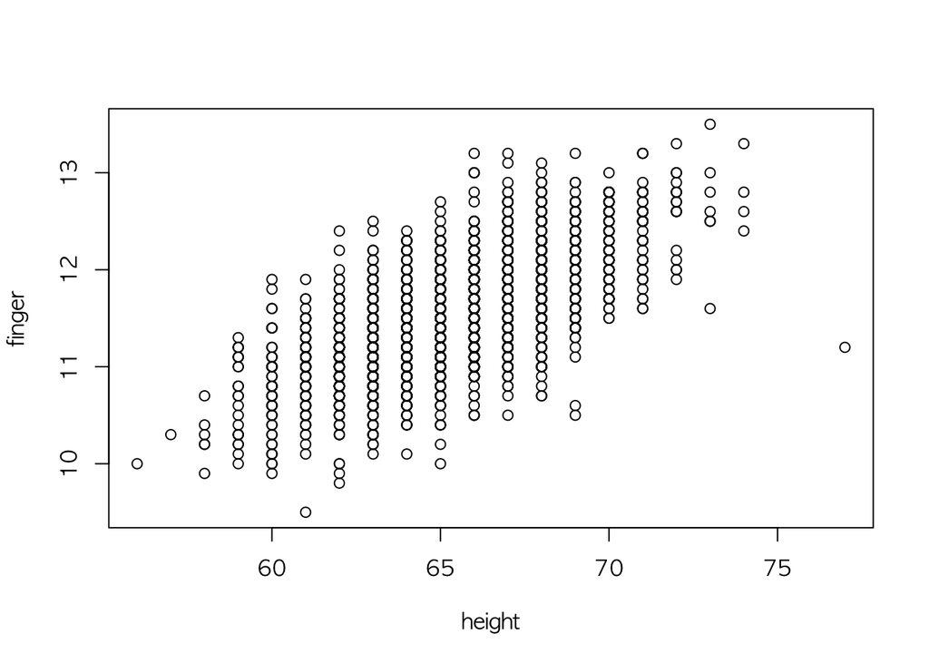

```r
plot(finger ~ height, data = crimtab.2.long.df)
```

- 변수 각각의 히스토그램은?

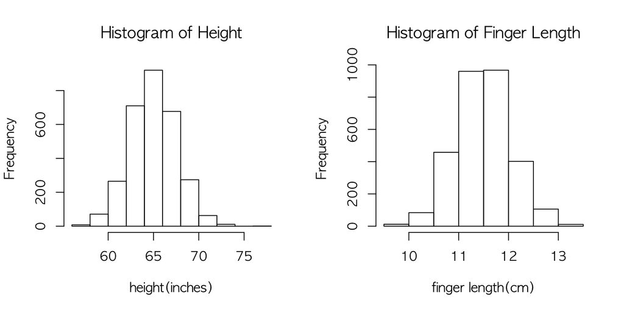

```r
par(mfrow=c(1,2))
hist(crimtab.2.long.df$height, main="Histogram of Height", xlab="height(inches)")
hist(crimtab.2.long.df$finger, main="Histogram of Finger Length", xlab= "finger length(cm)")
```

```r
# hist(crimtab.2.long.df["height"], main="Histogram of Height", xlab="height(inches)")
# hist(crimtab.2.long.df["finger"], main="Histogram of Finger Length", xlab= "finger length(cm)")
```

- 평균과 표준편차를 한번에 구하려면 다음과 같이 anonymous function을 작성하고 `mapply()`를 이용하는 게 편함. 이를 모수로 하는 정규곡선을 덧씌워 볼 것.
  - `mean.sd()`도 anonymous function 으로 평균과 표준편차를 계산해서 출력하는 함수임. 이와 같은 함수를 저장해 놓으려면 `dump()`를 이용함.
  - 이와 같이 계산한 평균과 표준편차를 모수로 하는 정규곡선을 덧씌워 볼 것.

```r
mean.sd <- function(x) {
  mean <- mean(x, na.rm = TRUE)
  sd <- sd(x)
  list(mean = mean, sd = sd)
}
(crimtab.stat <- mapply(mean.sd, crimtab.2.long.df))
```

```
##      finger    height
## mean 11.54737  65.473
## sd   0.5487137 2.557757
```

```r
str(crimtab.stat)
```

```
## List of 4
##  $ : num 11.5
##  $ : num 0.549
##  $ : num 65.5
##  $ : num 2.56
##  - attr(*, "dim")= int [1:2] 2 2
##  - attr(*, "dimnames")=List of 2
##   ..$ : chr [1:2] "mean" "sd"
##   ..$ : chr [1:2] "finger" "height"
```

```r
# apply(crimtab.2.long, 2, mean)
# apply(crimtab.2.long, 2, sd)
dump("mean.sd", file="mean_sd.R")
```

- `crimtab.stat`이 어떤 성격을 갖는지 다음 질문과 추출 작업을 통해서 알아보자.

```r
is.matrix(crimtab.stat)
```

```
## [1] TRUE
```

```r
is.table(crimtab.stat)
```

```
## [1] FALSE
```

```r
is.list(crimtab.stat)
```

```
## [1] TRUE
```

```r
is.data.frame(crimtab.stat)
```

```
## [1] FALSE
```

```r
crimtab.stat[, 1]
```

```
## $mean
## [1] 11.54737
##
## $sd
## [1] 0.5487137
```

```r
crimtab.stat[, "finger"]
```

```
## $mean
## [1] 11.54737
##
## $sd
## [1] 0.5487137
```

```r
crimtab.stat[, "finger"][1]
```

```
## $mean
## [1] 11.54737
```

```r
crimtab.stat[, "finger"][[1]]
```

```
## [1] 11.54737
```

```r
crimtab.stat[1]
```

```
## [[1]]
## [1] 11.54737
```

```r
crimtab.stat["finger"]
```

[output not shown]

```r
crimtab.stat$finger
```

[output not shown]

```r
(crimtab.stat.df <- data.frame(crimtab.stat))
```

```
##         finger   height
## mean  11.54737   65.473
## sd   0.5487137 2.557757
```

```r
is.matrix(crimtab.stat.df)
```

```
## [1] FALSE
```

```r
is.table(crimtab.stat.df)
```

```
## [1] FALSE
```

```r
is.list(crimtab.stat.df)
```

```
## [1] TRUE
```

```r
is.data.frame(crimtab.stat.df)
```

```
## [1] TRUE
```

```r
crimtab.stat.df[, 1]
```

```
## $mean
## [1] 11.54737
##
## $sd
## [1] 0.5487137
```

```r
str(crimtab.stat.df[, 1])
```

```
## List of 2
##  $ mean: num 11.5
##  $ sd  : num 0.549
```

```r
crimtab.stat.df[, "finger"]
```

```
## $mean
## [1] 11.54737
##
## $sd
## [1] 0.5487137
```

```r
str(crimtab.stat.df[, "finger"])
```

```
## List of 2
##  $ mean: num 11.5
##  $ sd  : num 0.549
```

```r
crimtab.stat.df[, "finger"][1]
```

```
## $mean
## [1] 11.54737
```

```r
str(crimtab.stat.df[, "finger"][1])
```

```
## List of 1
##  $ mean: num 11.5
```

```r
crimtab.stat.df[, "finger"][[1]]
```

```
## [1] 11.54737
```

```r
str(crimtab.stat.df[, "finger"][[1]])
```

```
##  num 11.5
```

```r
crimtab.stat.df[1]
```

```
##         finger
## mean  11.54737
## sd   0.5487137
```

```r
str(crimtab.stat.df[1])
```

```
## 'data.frame':    2 obs. of  1 variable:
##  $ finger:List of 2
##   ..$ mean: num 11.5
##   ..$ sd  : num 0.549
```

```r
crimtab.stat.df["finger"]
```

```
##         finger
## mean  11.54737
## sd   0.5487137
```

```r
str(crimtab.stat.df["finger"])
```

```
## 'data.frame':    2 obs. of  1 variable:
##  $ finger:List of 2
##   ..$ mean: num 11.5
##   ..$ sd  : num 0.549
```

```r
crimtab.stat.df["finger"][1]
```

```
##         finger
## mean  11.54737
## sd   0.5487137
```

```r
str(crimtab.stat.df["finger"][1])
```

```
## 'data.frame':    2 obs. of  1 variable:
##  $ finger:List of 2
##   ..$ mean: num 11.5
##   ..$ sd  : num 0.549
```

```r
crimtab.stat.df["finger"][[1]]
```

```
## $mean
## [1] 11.54737
##
## $sd
## [1] 0.5487137
```

```r
str(crimtab.stat.df["finger"][[1]])
```

```
## List of 2
##  $ mean: num 11.5
##  $ sd  : num 0.549
```

```r
crimtab.stat.df$finger
```

```
## $mean
## [1] 11.54737
##
## $sd
## [1] 0.5487137
```

```r
str(crimtab.stat.df$finger)
```

```
## List of 2
##  $ mean: num 11.5
##  $ sd  : num 0.549
```

```r
crimtab.stat.df$finger[1]
```

```
## $mean
## [1] 11.54737
```

```r
str(crimtab.stat.df$finger[1])
```

```
## List of 1
##  $ mean: num 11.5
```

```r
crimtab.stat.df$finger[[1]]
```

```
## [1] 11.54737
```

```r
str(crimtab.stat.df$finger[[1]])
```

```
##  num 11.5
```

### ggplot

- 키와 손가락 길이의 산점도

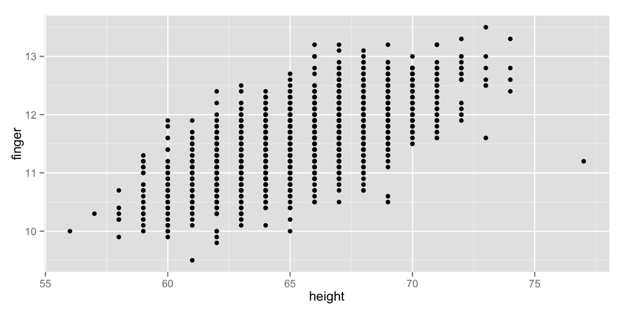

```r
library(ggplot2)
ggplot(crimtab.2.long.df, aes(x = height, y = finger)) + geom_point()
```

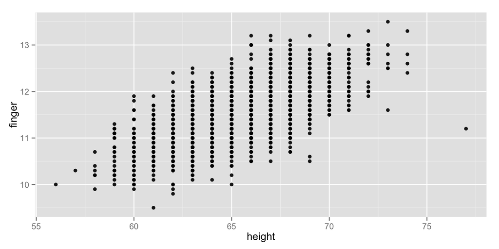

```r
ggplot(crimtab.2.long.df, aes(x = height, y = finger)) + geom_point(alpha = 0.9)
```

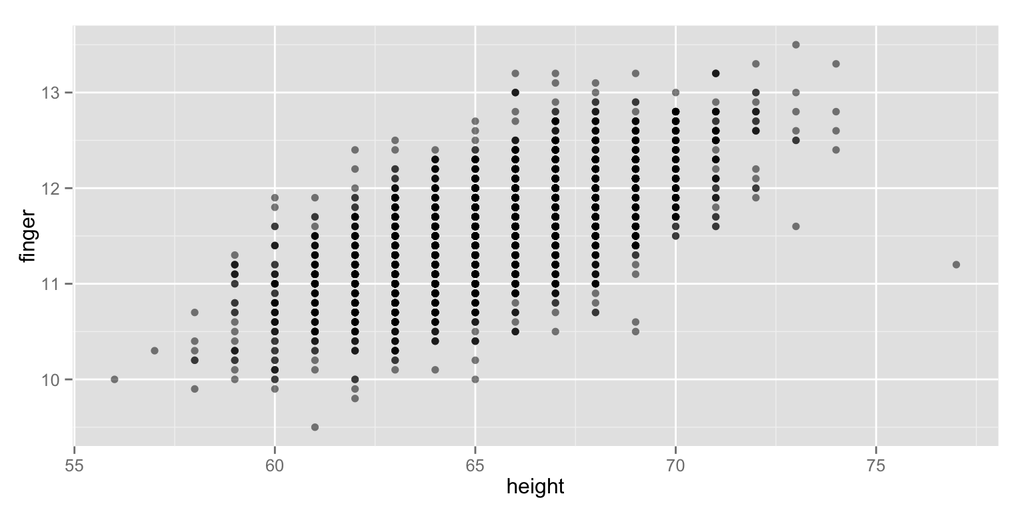

```r
ggplot(crimtab.2.long.df, aes(x = height, y = finger)) + geom_point(alpha = 0.5)
```

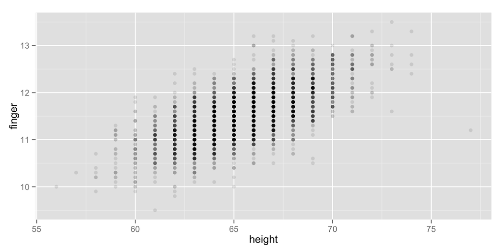

```r
ggplot(crimtab.2.long.df, aes(x = height, y = finger)) + geom_point(alpha = 0.1)
```

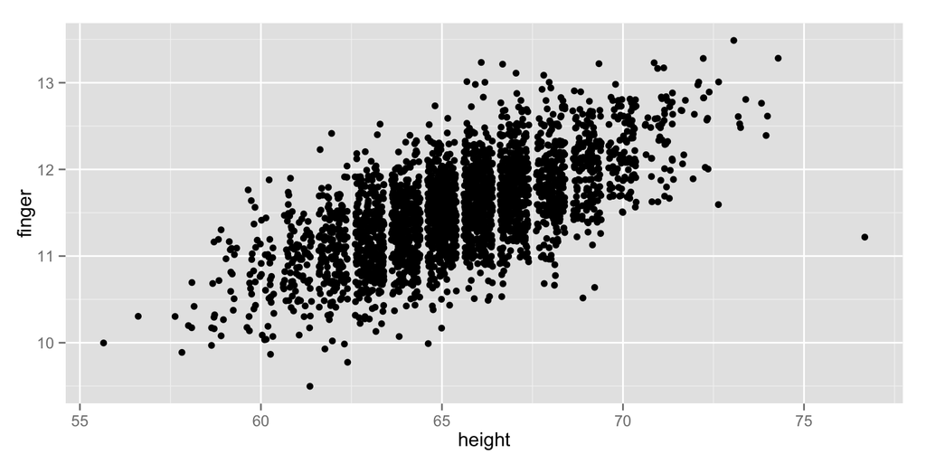

```r
ggplot(crimtab.2.long.df, aes(x = height, y = finger)) + geom_point(position = "jitter")
```

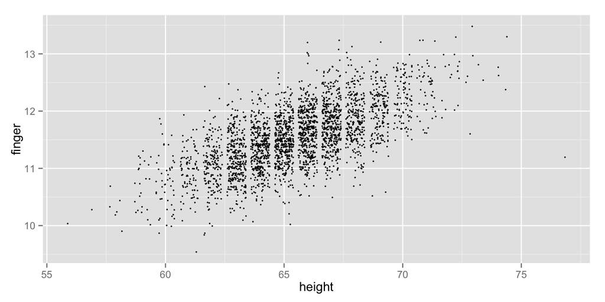

```r
ggplot(crimtab.2.long.df, aes(x = height, y = finger)) + geom_point(position = "jitter", size = 0.7)
```

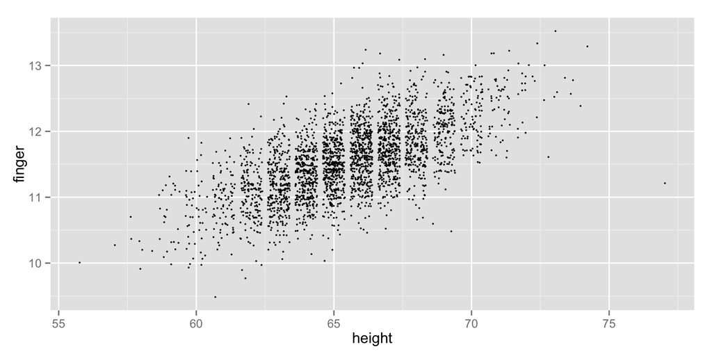

```r
ggplot(crimtab.2.long.df, aes(x = height, y = finger)) + geom_point(position = position_jitter(), size = 0.7)
```

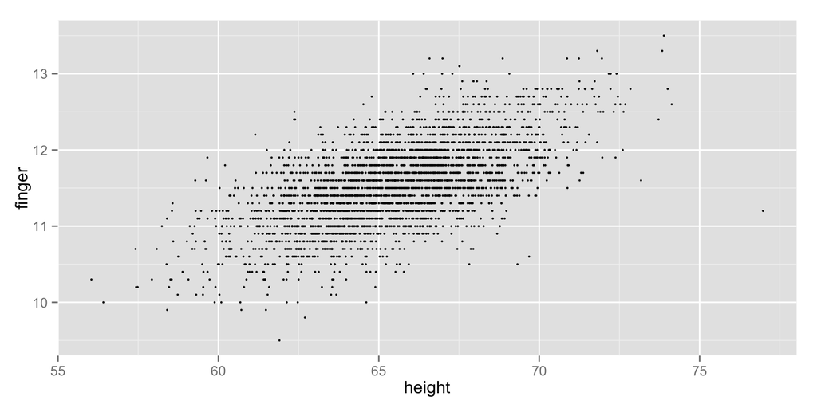

```r
ggplot(crimtab.2.long.df, aes(x = height, y = finger)) + geom_point(position = position_jitter(width = 1, height = 0), size = 0.7)
```

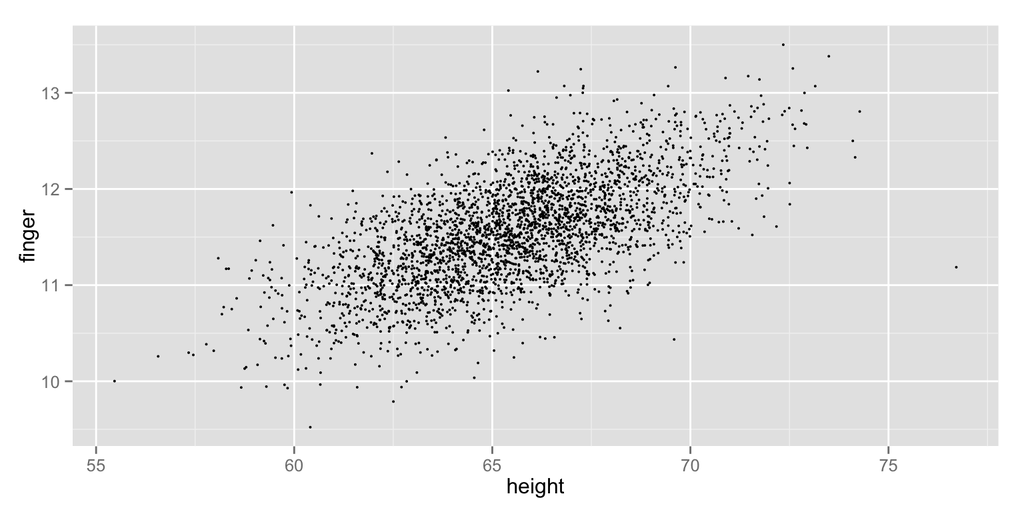

```r
ggplot(crimtab.2.long.df, aes(x = height, y = finger)) + geom_point(position = position_jitter(width = 1, height = 0.1), size = 0.7)
```

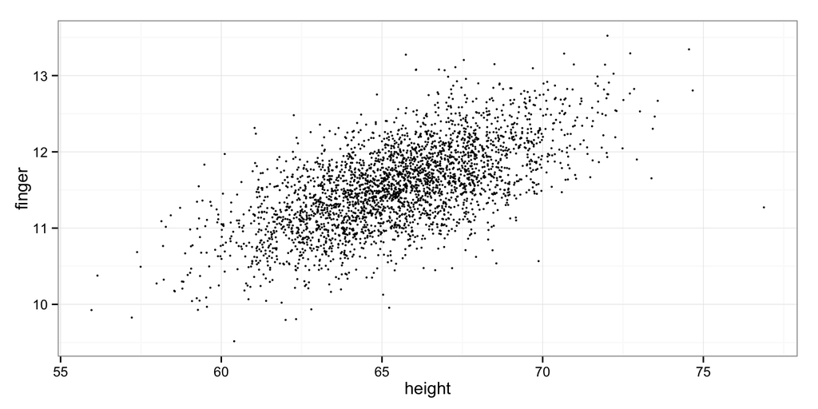

```r
ggplot(crimtab.2.long.df, aes(x = height, y = finger)) + geom_point(position = position_jitter(width = 1, height = 0.1), size = 0.7) +
  theme_bw()
```

- 변수 각각의 히스토그램

```
## stat_bin: binwidth defaulted to range/30. Use 'binwidth = x' to adjust this.
```

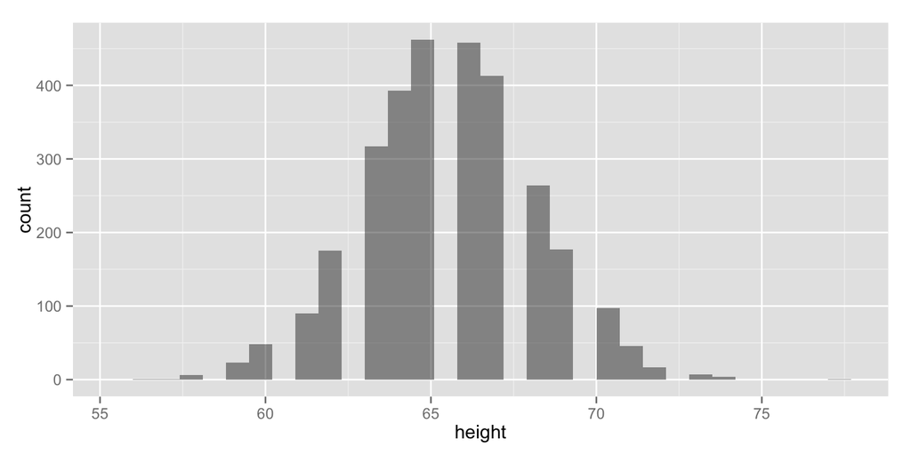

```r
ggplot(crimtab.2.long.df, aes(x = height)) + geom_histogram(alpha=0.5)
```

```
## stat_bin: binwidth defaulted to range/30. Use 'binwidth = x' to adjust this.
```

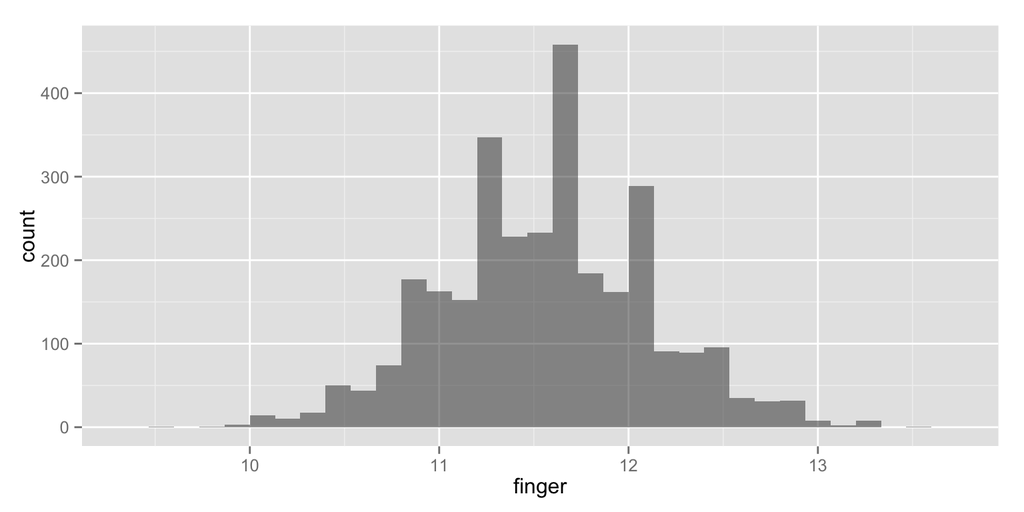

```r
ggplot(crimtab.2.long.df, aes(x = finger)) + geom_histogram(alpha=0.5)
```

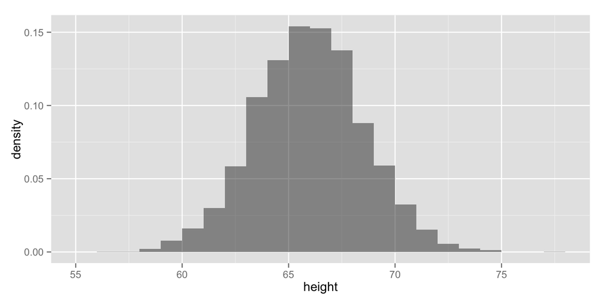

```r
ggplot(crimtab.2.long.df, aes(x = height)) + geom_histogram(aes(y = ..density..), binwidth=1, alpha=0.5)
```

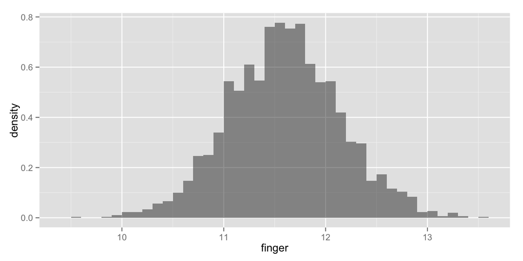

```r
ggplot(crimtab.2.long.df, aes(x = finger)) + geom_histogram(aes(y = ..density..), binwidth=0.1, alpha=0.5)
```

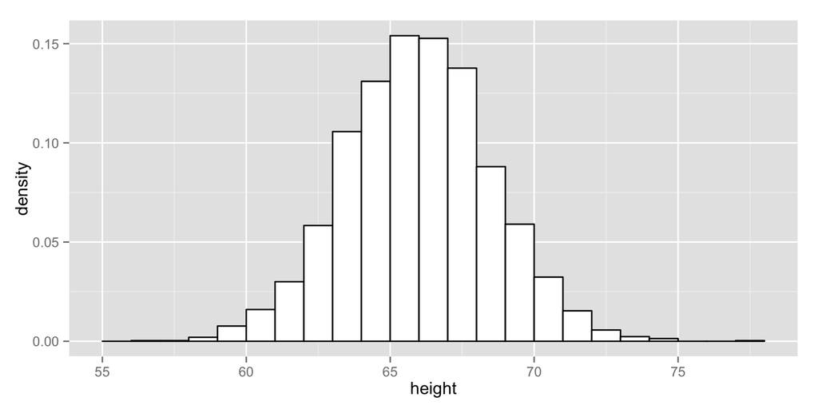

```r
(g.h.1 <- ggplot(crimtab.2.long.df, aes(x = height)) + geom_histogram(aes(y = ..density..), binwidth = 1, fill = "white", colour = "black"))
```

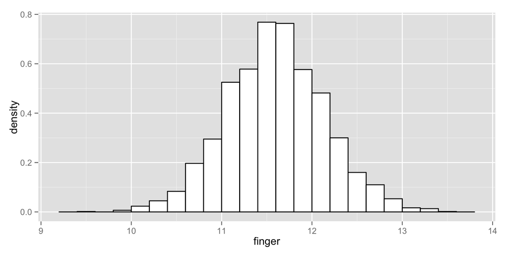

```r
(g.f.1 <- ggplot(crimtab.2.long.df, aes(x = finger)) + geom_histogram(aes(y = ..density..), binwidth = 0.2, fill = "white", colour = "black"))
```

- `breaks` 설정의 필요성
  - default 로 그린 히스토그램에 평균과 표준편차를 위치시켜보면, Quetelet의 가슴둘레 자료를 히스토그램으로 표현할 때와 같이 0.5만큼 치우친 것을 알 수 있음.
  - 따라서 `geom_histogram`의 원형인 `stat_bin`에 `breaks=`를 재설정할 필요.

```r
library(grid)
(mean.finger <- crimtab.stat[, 1][[1]])
```

```
## [1] 11.54737
```

```r
(sd.finger <- crimtab.stat[, 1][[2]])
```

```
## [1] 0.5487137
```

```r
(mean.height <- crimtab.stat[, 2][[1]])
```

```
## [1] 65.473
```

```r
(sd.height <- crimtab.stat[, 2][[2]])
```

```
## [1] 2.557757
```

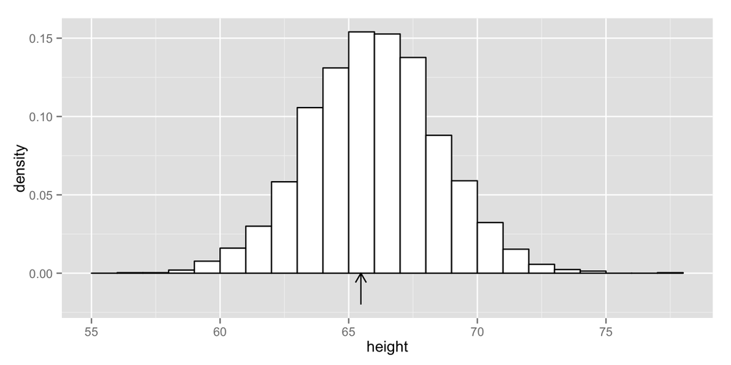

```r
x.finger <- seq(9.5, 13.5, length.out = 3000)
y.finger <- dnorm(x.finger, mean = mean.finger, sd = sd.finger)
x.height <- seq(56, 77, length.out = 3000)
y.height <- dnorm(x.height, mean = mean.height, sd = sd.height)
(g.h.2 <- g.h.1 + annotate("segment", x = mean.height, xend = mean.height, y= -0.02, yend = 0, arrow = arrow(length=unit(0.3, "cm"))))
```

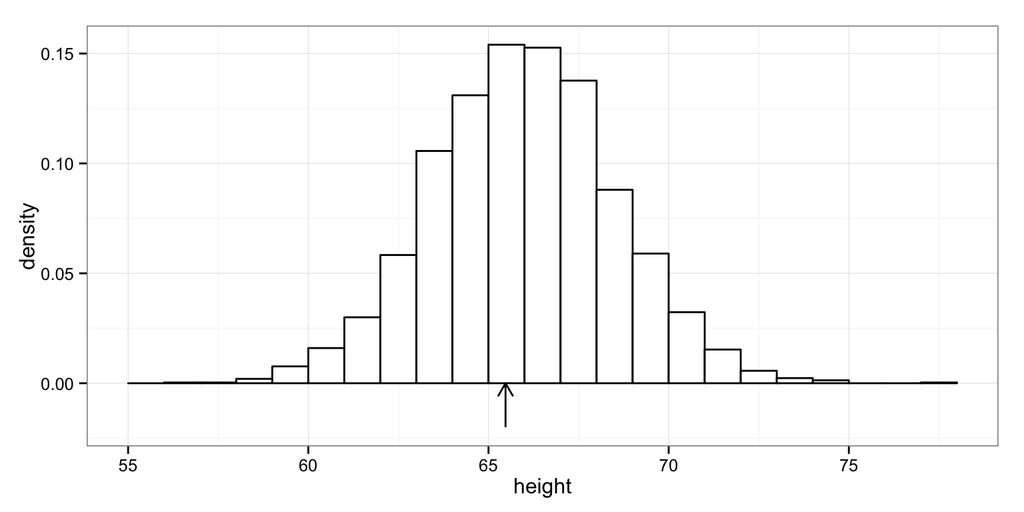

```r
(g.h.3 <- g.h.2 + theme_bw())
```

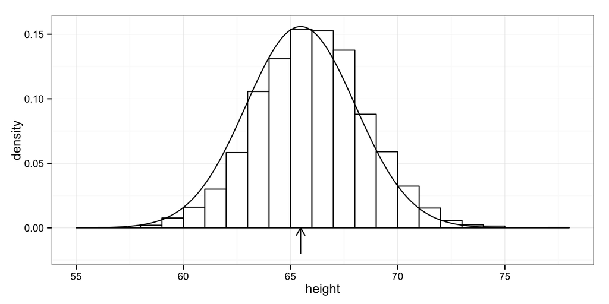

```r
(g.h.4 <- g.h.3 + geom_line(aes(x = x.height, y = y.height)))
```

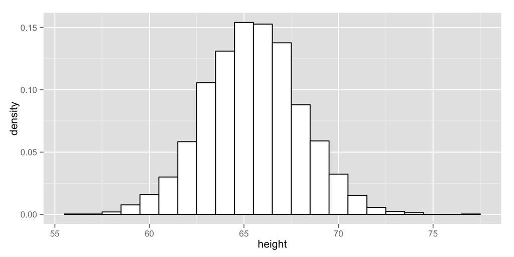

```r
(g.h.5 <- ggplot(crimtab.2.long.df, aes(x = height)) + stat_bin(aes(y = ..density..), binwidth = 1, breaks = 55.5:77.5, fill = "white", colour="black"))
```

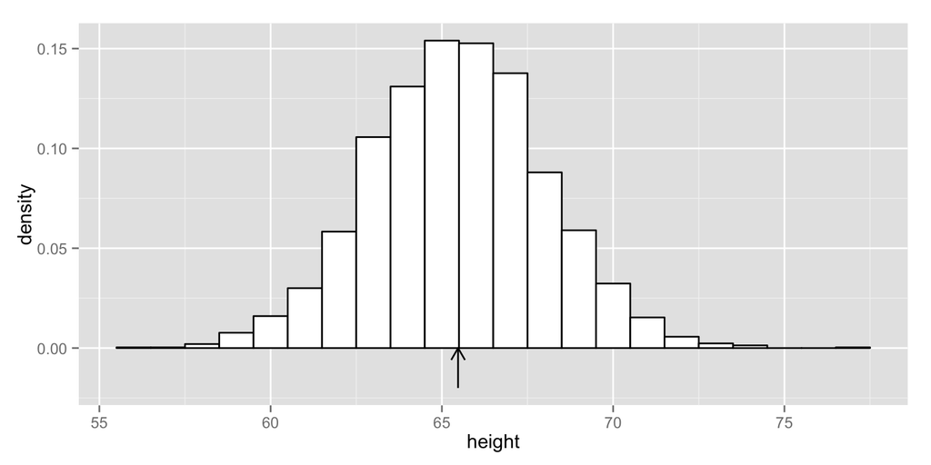

```r
(g.h.6 <- g.h.5 + annotate("segment", x = mean.height, xend = mean.height, y= -0.02, yend = 0, arrow = arrow(length = unit(0.3, "cm"))))
```

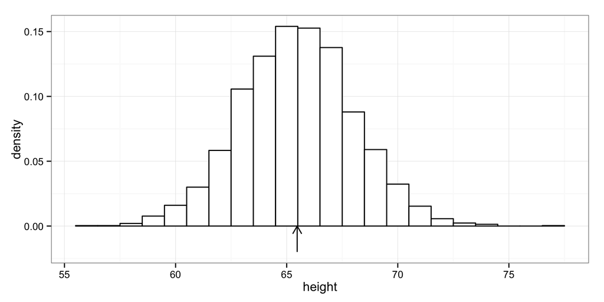

```r
(g.h.7 <- g.h.6 + theme_bw())
```

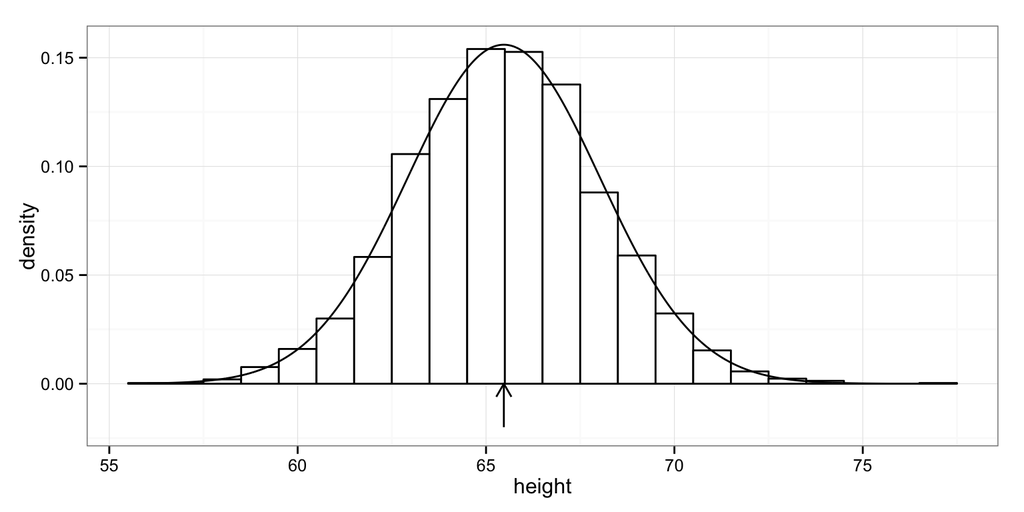

```r
(g.h.8 <- g.h.7 + geom_line(aes(x = x.height, y = y.height)))
```

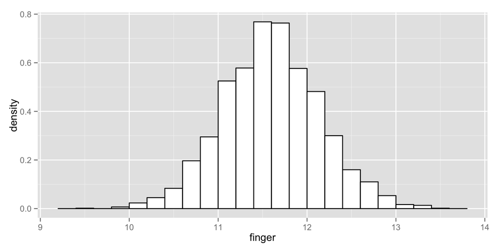

```r
(g.f.1 <- ggplot(crimtab.2.long.df, aes(x = finger)) + geom_histogram(aes(y = ..density..), binwidth = 0.2, fill = "white", colour = "black"))
```

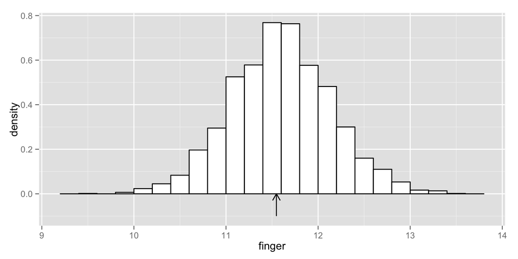

```r
(g.f.2 <- g.f.1 + annotate("segment", x = mean.finger, xend = mean.finger, y= -0.1, yend = 0, arrow = arrow(length = unit(0.3, "cm"))))
```

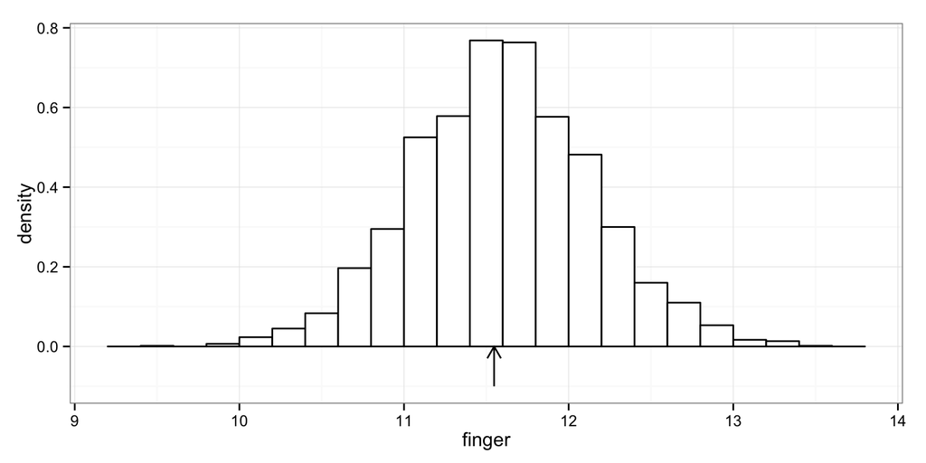

```r
(g.f.3 <- g.f.2 + theme_bw())
```